# ML

Title : Explainable AI for Comparative Analysis of Intrusion Detection Models

Prompt: generate python code to load UNSW dataset and display first few rows

```python
import pandas as pd

df = pd.read_csv('/content/UNSW_NB15.csv')
display(df.head())
```

|  | id | dur | proto | service | state | spkts | dpkts | sbytes | dbytes | rate | ... | ct_dst_sport_ltm | ct_dst_src_ltm | is_ftp_login | ct_ftp_cmd | ct_flw_http_mthd | ct_src_ltm | ct_srv_dst | is_sm_ips_ports | attack_cat | label |
| --- | --- | --- | --- | --- | --- | --- | --- | --- | --- | --- | --- | --- | --- | --- | --- | --- | --- | --- | --- | --- | --- |
| 0 | 1 | 0.121478 | tcp | - | FIN | 6 | 4 | 258 | 172 | 74.087490 | ... | 1 | 1 | 0 | 0 | 0 | 1 | 1 | 0 | Normal | 0 |
| 1 | 2 | 0.649902 | tcp | - | FIN | 14 | 38 | 734 | 42014 | 78.473372 | ... | 1 | 2 | 0 | 0 | 0 | 1 | 6 | 0 | Normal | 0 |
| 2 | 3 | 1.623129 | tcp | - | FIN | 8 | 16 | 364 | 13186 | 14.170161 | ... | 1 | 3 | 0 | 0 | 0 | 2 | 6 | 0 | Normal | 0 |
| 3 | 4 | 1.681642 | tcp | ftp | FIN | 12 | 12 | 628 | 770 | 13.677108 | ... | 1 | 3 | 1 | 1 | 0 | 2 | 1 | 0 | Normal | 0 |
| 4 | 5 | 0.449454 | tcp | - | FIN | 10 | 6 | 534 | 268 | 33.373826 | ... | 1 | 40 | 0 | 0 | 0 | 2 | 39 | 0 | Normal | 0 |

5 rows × 45 columns

Inference: The UNSW-NB15 dataset is successfully loaded and contains network traffic records with features and labels.

Prompt: generate python code to show dataset shape, columns and information

```python
print(f"Dataset shape: {df.shape}")
print("\nDataset columns:")
display(df.columns)
print("\nDataset information:")
df.info()
```

```
Dataset shape: (175341, 45)

Dataset columns:
```

```
Index(['id', 'dur', 'proto', 'service', 'state', 'spkts', 'dpkts', 'sbytes',
       'dbytes', 'rate', 'sttl', 'dttl', 'sload', 'dload', 'sloss', 'dloss',
       'sinpkt', 'dinpkt', 'sjit', 'djit', 'swin', 'stcpb', 'dtcpb', 'dwin',
       'tcprtt', 'synack', 'ackdat', 'smean', 'dmean', 'trans_depth',
       'response_body_len', 'ct_srv_src', 'ct_state_ttl', 'ct_dst_ltm',
       'ct_src_dport_ltm', 'ct_dst_sport_ltm', 'ct_dst_src_ltm',
       'is_ftp_login', 'ct_ftp_cmd', 'ct_flw_http_mthd', 'ct_src_ltm',
       'ct_srv_dst', 'is_sm_ips_ports', 'attack_cat', 'label'],
      dtype='object')
```

```
Dataset information:
<class 'pandas.core.frame.DataFrame'>
RangeIndex: 175341 entries, 0 to 175340
Data columns (total 45 columns):
 #   Column             Non-Null Count   Dtype
---  ------             --------------   -----
 0   id                 175341 non-null  int64
 1   dur                175341 non-null  float64
 2   proto              175341 non-null  object
 3   service            175341 non-null  object
 4   state              175341 non-null  object
 5   spkts              175341 non-null  int64
 6   dpkts              175341 non-null  int64
 7   sbytes             175341 non-null  int64
 8   dbytes             175341 non-null  int64
```

[output cut: 38 more lines]

Inference: Dataset contains multiple features including network attributes and attack labels used for intrusion detection.

Prompt: generate python code to check missing values

```python
missing_values = df.isnull().sum()
missing_values = missing_values[missing_values > 0]
if not missing_values.empty:
    print("Columns with missing values and their counts:")
    display(missing_values)
else:
    print("No missing values found in the dataset.")
```

```
No missing values found in the dataset.
```

Prompt: generate python code to remove missing values and duplicates

```python
print(f"DataFrame shape before removing duplicates: {df.shape}")
df.drop_duplicates(inplace=True)
print(f"DataFrame shape after removing duplicates: {df.shape}")
```

```
DataFrame shape before removing duplicates: (175341, 45)
DataFrame shape after removing duplicates: (175341, 45)
```

Prompt: generate python code to visualize attack category distribution using pie chart

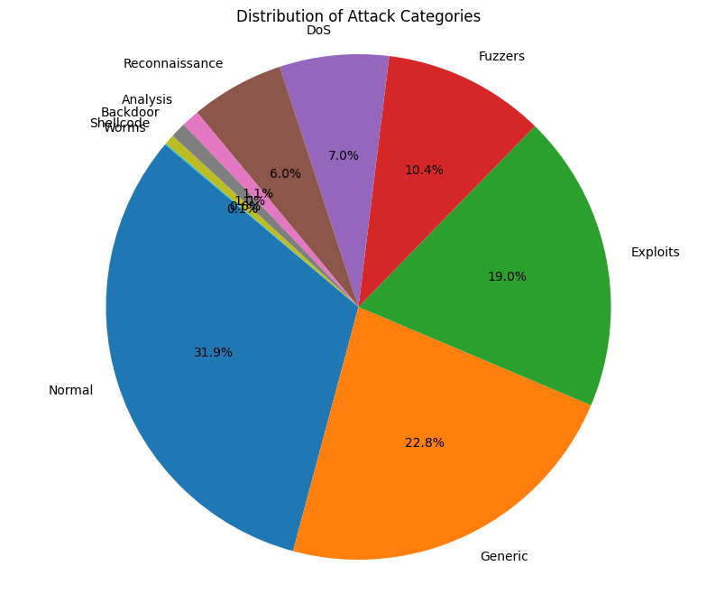

```python
import matplotlib.pyplot as plt

attack_category_distribution = df['attack_cat'].value_counts()

plt.figure(figsize=(10, 8))
plt.pie(attack_category_distribution, labels=attack_category_distribution.index, autopct='%1.1f%%', startangle=140)
plt.title('Distribution of Attack Categories')
plt.axis('equal') # Equal aspect ratio ensures that pie is drawn as a circle.
plt.show()
```

Inference: The dataset contains multiple attack categories along with normal traffic, showing class imbalance.

Prompt: generate python code to visualize correlation between features using heatmap

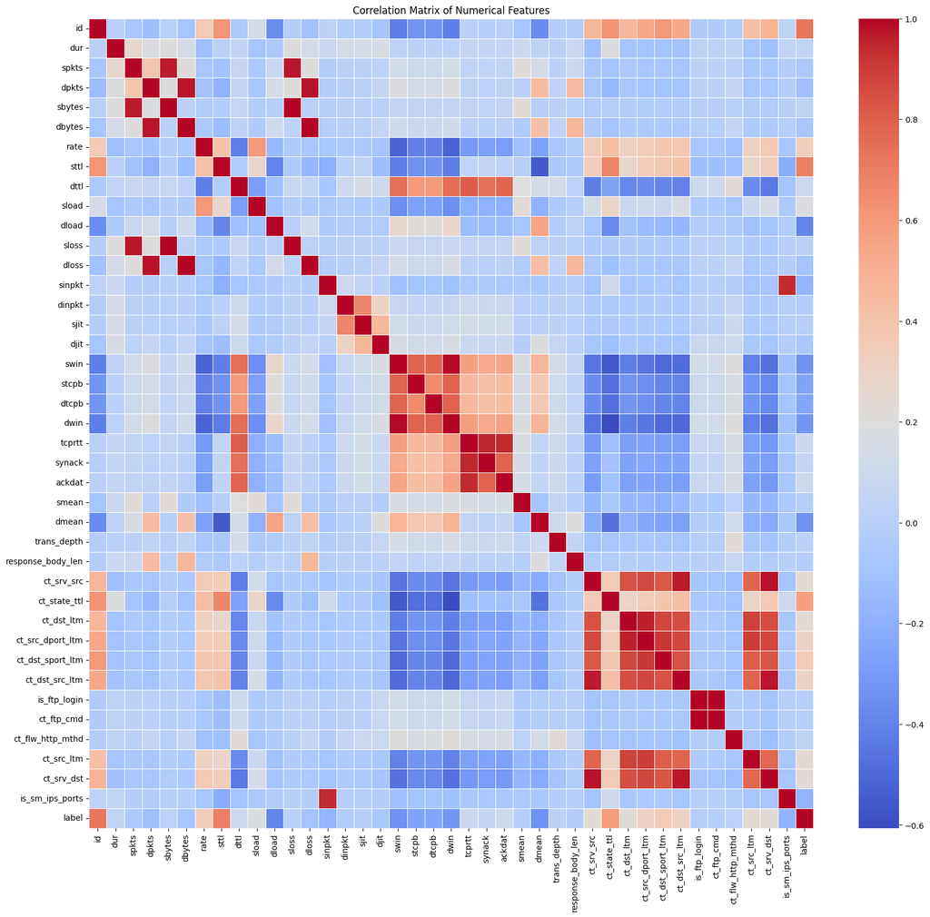

```python
import seaborn as sns
import matplotlib.pyplot as plt

# Select only numerical columns for correlation calculation
numerical_df = df.select_dtypes(include=['float64', 'int64'])

# Calculate the correlation matrix
correlation_matrix = numerical_df.corr()

# Plot the heatmap
plt.figure(figsize=(20, 18))
sns.heatmap(correlation_matrix, annot=False, cmap='coolwarm', fmt=".2f", linewidths=.5)
plt.title('Correlation Matrix of Numerical Features')
plt.show()
```

Prompt: generate python code to convert categorical data into numerical form

```python
from sklearn.preprocessing import LabelEncoder

# Identify categorical columns (excluding 'label' as it's already numerical target)
categorical_cols = df.select_dtypes(include='object').columns.tolist()

# Handle 'attack_cat' separately with LabelEncoder as it's a target variable
if 'attack_cat' in categorical_cols:
    le = LabelEncoder()
    df['attack_cat_encoded'] = le.fit_transform(df['attack_cat'])
    categorical_cols.remove('attack_cat')

# Apply One-Hot Encoding to the remaining categorical columns
# using pd.get_dummies to convert them into numerical format.
df_encoded = pd.get_dummies(df, columns=categorical_cols, drop_first=True)

print("Original DataFrame shape:", df.shape)
print("DataFrame shape after encoding:", df_encoded.shape)
print("\nFirst few rows of the encoded DataFrame:")
display(df_encoded.head())
print("\nUnique values and their counts for 'attack_cat_encoded':")
display(df_encoded['attack_cat_encoded'].value_counts())
```

```
Original DataFrame shape: (175341, 46)
DataFrame shape after encoding: (175341, 195)

First few rows of the encoded DataFrame:
```

|  | id | dur | spkts | dpkts | sbytes | dbytes | rate | sttl | dttl | sload | ... | service_ssh | service_ssl | state_ECO | state_FIN | state_INT | state_PAR | state_REQ | state_RST | state_URN | state_no |
| --- | --- | --- | --- | --- | --- | --- | --- | --- | --- | --- | --- | --- | --- | --- | --- | --- | --- | --- | --- | --- | --- |
| 0 | 1 | 0.121478 | 6 | 4 | 258 | 172 | 74.087490 | 252 | 254 | 14158.942380 | ... | False | False | False | True | False | False | False | False | False | False |
| 1 | 2 | 0.649902 | 14 | 38 | 734 | 42014 | 78.473372 | 62 | 252 | 8395.112305 | ... | False | False | False | True | False | False | False | False | False | False |
| 2 | 3 | 1.623129 | 8 | 16 | 364 | 13186 | 14.170161 | 62 | 252 | 1572.271851 | ... | False | False | False | True | False | False | False | False | False | False |
| 3 | 4 | 1.681642 | 12 | 12 | 628 | 770 | 13.677108 | 62 | 252 | 2740.178955 | ... | False | False | False | True | False | False | False | False | False | False |
| 4 | 5 | 0.449454 | 10 | 6 | 534 | 268 | 33.373826 | 254 | 252 | 8561.499023 | ... | False | False | False | True | False | False | False | False | False | False |

5 rows × 195 columns

```
Unique values and their counts for 'attack_cat_encoded':
```

| attack_cat_encoded | count |
| --- | --- |
| 6 | 56000 |
| 5 | 40000 |
| 3 | 33393 |
| 4 | 18184 |
| 2 | 12264 |
| 7 | 10491 |
| 0 | 2000 |
| 1 | 1746 |
| 8 | 1133 |
| 9 | 130 |

**dtype:** int64

Inference: Categorical features are converted into numerical values for machine learning models.

Prompt: generate python code to split dataset into features and target

```python
X = df_encoded.drop(columns=['label', 'attack_cat_encoded', 'id', 'attack_cat'])
y = df_encoded['label']

print(f"Features (X) shape: {X.shape}")
print(f"Target (y) shape: {y.shape}")

print("\nFirst few rows of features (X):")
display(X.head())

print("\nFirst few rows of target (y):")
display(y.head())
```

```
Features (X) shape: (175341, 191)
Target (y) shape: (175341,)

First few rows of features (X):
```

|  | dur | spkts | dpkts | sbytes | dbytes | rate | sttl | dttl | sload | dload | ... | service_ssh | service_ssl | state_ECO | state_FIN | state_INT | state_PAR | state_REQ | state_RST | state_URN | state_no |
| --- | --- | --- | --- | --- | --- | --- | --- | --- | --- | --- | --- | --- | --- | --- | --- | --- | --- | --- | --- | --- | --- |
| 0 | 0.121478 | 6 | 4 | 258 | 172 | 74.087490 | 252 | 254 | 14158.942380 | 8495.365234 | ... | False | False | False | True | False | False | False | False | False | False |
| 1 | 0.649902 | 14 | 38 | 734 | 42014 | 78.473372 | 62 | 252 | 8395.112305 | 503571.312500 | ... | False | False | False | True | False | False | False | False | False | False |
| 2 | 1.623129 | 8 | 16 | 364 | 13186 | 14.170161 | 62 | 252 | 1572.271851 | 60929.230470 | ... | False | False | False | True | False | False | False | False | False | False |
| 3 | 1.681642 | 12 | 12 | 628 | 770 | 13.677108 | 62 | 252 | 2740.178955 | 3358.622070 | ... | False | False | False | True | False | False | False | False | False | False |
| 4 | 0.449454 | 10 | 6 | 534 | 268 | 33.373826 | 254 | 252 | 8561.499023 | 3987.059814 | ... | False | False | False | True | False | False | False | False | False | False |

5 rows × 191 columns

```
First few rows of target (y):
```

|  | label |
| --- | --- |
| 0 | 0 |
| 1 | 0 |
| 2 | 0 |
| 3 | 0 |
| 4 | 0 |

**dtype:** int64

Inference: Features and target variable are separated for model training.

```python
from sklearn.metrics import accuracy_score, classification_report
```

Prompt: train Naive Bayes model for intrusion detection and evaluate its performance

```python
from sklearn.model_selection import train_test_split
from sklearn.naive_bayes import GaussianNB
from sklearn.metrics import accuracy_score, classification_report, confusion_matrix
import matplotlib.pyplot as plt
import seaborn as sns
```

```python
# Split data into training and testing sets
X_train, X_test, y_train, y_test = train_test_split(X, y, test_size=0.3, random_state=42)

print(f"X_train shape: {X_train.shape}")
print(f"X_test shape: {X_test.shape}")
print(f"y_train shape: {y_train.shape}")
print(f"y_test shape: {y_test.shape}")
```

```
X_train shape: (122738, 191)
X_test shape: (52603, 191)
y_train shape: (122738,)
y_test shape: (52603,)
```

### Naive Bayes Model Training and Evaluation

```
Naive Bayes Model Accuracy: 0.7907

Classification Report for Naive Bayes:
              precision    recall  f1-score   support

           0       0.67      0.67      0.67     16772
           1       0.84      0.85      0.85     35831

    accuracy                           0.79     52603
   macro avg       0.76      0.76      0.76     52603
weighted avg       0.79      0.79      0.79     52603
```

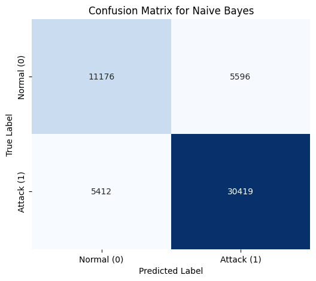

```python
# Initialize Gaussian Naive Bayes classifier
nb_model = GaussianNB()

# Train the model
nb_model.fit(X_train, y_train)

# Make predictions on the test set
y_pred_nb = nb_model.predict(X_test)

# Evaluate the model
accuracy_nb = accuracy_score(y_test, y_pred_nb)
print(f"Naive Bayes Model Accuracy: {accuracy_nb:.4f}")

print("\nClassification Report for Naive Bayes:")
print(classification_report(y_test, y_pred_nb))

# Confusion Matrix
cm_nb = confusion_matrix(y_test, y_pred_nb)
plt.figure(figsize=(6, 5))
sns.heatmap(cm_nb, annot=True, fmt='d', cmap='Blues', cbar=False,
            xticklabels=['Normal (0)', 'Attack (1)'], yticklabels=['Normal (0)', 'Attack (1)'])
plt.title('Confusion Matrix for Naive Bayes')
plt.xlabel('Predicted Label')
plt.ylabel('True Label')
plt.show()
```

Inference: Naive Bayes model is simple and fast. It performs reasonably well but assumes feature independence, which may reduce accuracy.

Prompt: train Logistic Regression model for intrusion detection and evaluate its performance

```
Logistic Regression Model Accuracy: 0.8492

Classification Report for Logistic Regression:
              precision    recall  f1-score   support

           0       0.89      0.60      0.72     16772
           1       0.84      0.96      0.90     35831

    accuracy                           0.85     52603
   macro avg       0.86      0.78      0.81     52603
weighted avg       0.85      0.85      0.84     52603
```

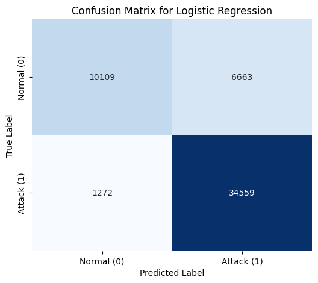

```python
from sklearn.linear_model import LogisticRegression

# Initialize Logistic Regression classifier
# Increased max_iter for convergence on this dataset
lr_model = LogisticRegression(max_iter=1000, random_state=42, solver='liblinear')

# Train the model
lr_model.fit(X_train, y_train)

# Make predictions on the test set
y_pred_lr = lr_model.predict(X_test)

# Evaluate the model
accuracy_lr = accuracy_score(y_test, y_pred_lr)
print(f"\nLogistic Regression Model Accuracy: {accuracy_lr:.4f}")

print("\nClassification Report for Logistic Regression:")
print(classification_report(y_test, y_pred_lr))

# Confusion Matrix
cm_lr = confusion_matrix(y_test, y_pred_lr)
plt.figure(figsize=(6, 5))
sns.heatmap(cm_lr, annot=True, fmt='d', cmap='Blues', cbar=False,
            xticklabels=['Normal (0)', 'Attack (1)'], yticklabels=['Normal (0)', 'Attack (1)'])
plt.title('Confusion Matrix for Logistic Regression')
plt.xlabel('Predicted Label')
plt.ylabel('True Label')
plt.show()
```

Inference: Logistic Regression shows better overall performance compared to Naive Bayes, with higher accuracy and strong recall for detecting attack instances, indicating its potential for intrusion detection.

Prompt: train K-Nearest Neighbors model for intrusion detection and evaluate its performance

```
K-Nearest Neighbors Model Accuracy: 0.8934

Classification Report for K-Nearest Neighbors:
              precision    recall  f1-score   support

           0       0.87      0.78      0.82     16772
           1       0.90      0.95      0.92     35831

    accuracy                           0.89     52603
   macro avg       0.89      0.86      0.87     52603
weighted avg       0.89      0.89      0.89     52603
```

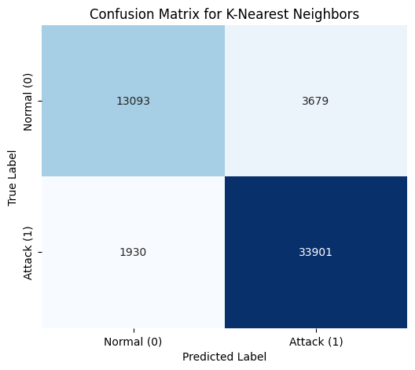

```python
from sklearn.neighbors import KNeighborsClassifier

# Initialize K-Nearest Neighbors classifier
# Choosing n_neighbors = 5 as a common starting point
knn_model = KNeighborsClassifier(n_neighbors=5)

# Train the model
knn_model.fit(X_train, y_train)

# Make predictions on the test set
y_pred_knn = knn_model.predict(X_test)

# Evaluate the model
accuracy_knn = accuracy_score(y_test, y_pred_knn)
print(f"\nK-Nearest Neighbors Model Accuracy: {accuracy_knn:.4f}")

print("\nClassification Report for K-Nearest Neighbors:")
print(classification_report(y_test, y_pred_knn))

# Confusion Matrix
cm_knn = confusion_matrix(y_test, y_pred_knn)
plt.figure(figsize=(6, 5))
sns.heatmap(cm_knn, annot=True, fmt='d', cmap='Blues', cbar=False,
            xticklabels=['Normal (0)', 'Attack (1)'], yticklabels=['Normal (0)', 'Attack (1)'])
plt.title('Confusion Matrix for K-Nearest Neighbors')
plt.xlabel('Predicted Label')
plt.ylabel('True Label')
plt.show()
```

Inference: K-Nearest Neighbors (KNN) model performance will be evaluated here, considering its strengths in capturing complex relationships without making strong assumptions about data distribution, but also its potential computational cost and sensitivity to feature scaling and dimensionality.

Prompt: train Decision Tree model for intrusion detection and evaluate its performance

```
Decision Tree Model Accuracy: 0.9481

Classification Report for Decision Tree:
              precision    recall  f1-score   support

           0       0.92      0.92      0.92     16772
           1       0.96      0.96      0.96     35831

    accuracy                           0.95     52603
   macro avg       0.94      0.94      0.94     52603
weighted avg       0.95      0.95      0.95     52603
```

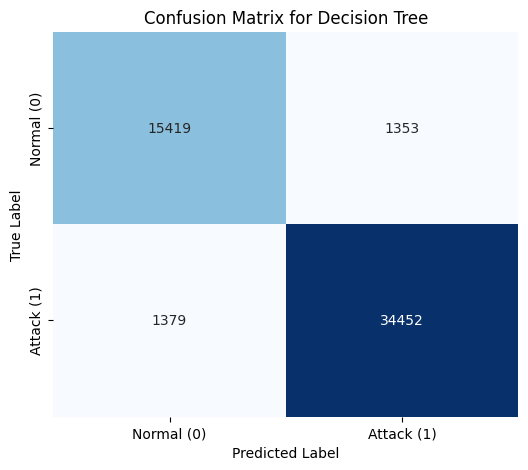

```python
from sklearn.tree import DecisionTreeClassifier

# Initialize Decision Tree classifier
dt_model = DecisionTreeClassifier(random_state=42)

# Train the model
dt_model.fit(X_train, y_train)

# Make predictions on the test set
y_pred_dt = dt_model.predict(X_test)

# Evaluate the model
accuracy_dt = accuracy_score(y_test, y_pred_dt)
print(f"\nDecision Tree Model Accuracy: {accuracy_dt:.4f}")

print("\nClassification Report for Decision Tree:")
print(classification_report(y_test, y_pred_dt))

# Confusion Matrix
cm_dt = confusion_matrix(y_test, y_pred_dt)
plt.figure(figsize=(6, 5))
sns.heatmap(cm_dt, annot=True, fmt='d', cmap='Blues', cbar=False,
            xticklabels=['Normal (0)', 'Attack (1)'], yticklabels=['Normal (0)', 'Attack (1)'])
plt.title('Confusion Matrix for Decision Tree')
plt.xlabel('Predicted Label')
plt.ylabel('True Label')
plt.show()
```

Inference: Decision Tree models are capable of capturing non-linear relationships and are generally easy to interpret. Their performance will be evaluated, considering factors like potential overfitting and their ability to handle the high-dimensional, mixed-type data present in the UNSW-NB15 dataset.

Prompt: train Artificial Neural Network (MLP) model for intrusion detection and evaluate its performance

```
Artificial Neural Network (MLP) Model Accuracy: 0.9464

Classification Report for MLP:
              precision    recall  f1-score   support

           0       0.94      0.89      0.91     16772
           1       0.95      0.97      0.96     35831

    accuracy                           0.95     52603
   macro avg       0.94      0.93      0.94     52603
weighted avg       0.95      0.95      0.95     52603
```

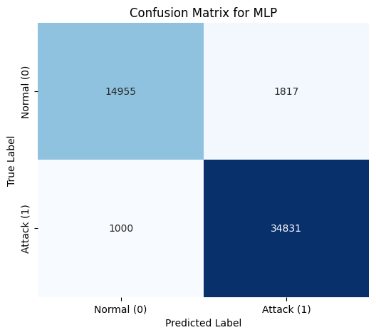

```python
from sklearn.neural_network import MLPClassifier
from sklearn.preprocessing import StandardScaler

# Scale the features for MLP
scaler = StandardScaler()
X_train_scaled = scaler.fit_transform(X_train)
X_test_scaled = scaler.transform(X_test)

# Initialize MLPClassifier
# Using a small hidden layer for demonstration, can be tuned.
# Increased max_iter for convergence.
mlp_model = MLPClassifier(hidden_layer_sizes=(100,), max_iter=300, random_state=42, solver='adam', early_stopping=True, n_iter_no_change=20)

# Train the model
mlp_model.fit(X_train_scaled, y_train)

# Make predictions on the test set
y_pred_mlp = mlp_model.predict(X_test_scaled)

# Evaluate the model
accuracy_mlp = accuracy_score(y_test, y_pred_mlp)
print(f"\nArtificial Neural Network (MLP) Model Accuracy: {accuracy_mlp:.4f}")

print("\nClassification Report for MLP:")
print(classification_report(y_test, y_pred_mlp))

# Confusion Matrix
cm_mlp = confusion_matrix(y_test, y_pred_mlp)
plt.figure(figsize=(6, 5))
sns.heatmap(cm_mlp, annot=True, fmt='d', cmap='Blues', cbar=False,
            xticklabels=['Normal (0)', 'Attack (1)'], yticklabels=['Normal (0)', 'Attack (1)'])
plt.title('Confusion Matrix for MLP')
plt.xlabel('Predicted Label')
plt.ylabel('True Label')
plt.show()
```

Inference: ANN can learn complex patterns and usually provides high accuracy, but requires more computation and tuning.

### Model Performance Comparison

Prompt: compare the performance of all trained machine learning models

```
Summary of Model Accuracies:
```

|  | Model | Accuracy |
| --- | --- | --- |
| 3 | Decision Tree | 0.948064 |
| 4 | Artificial Neural Network (MLP) | 0.946448 |
| 2 | K-Nearest Neighbors | 0.893371 |
| 1 | Logistic Regression | 0.849153 |
| 0 | Naive Bayes | 0.790734 |

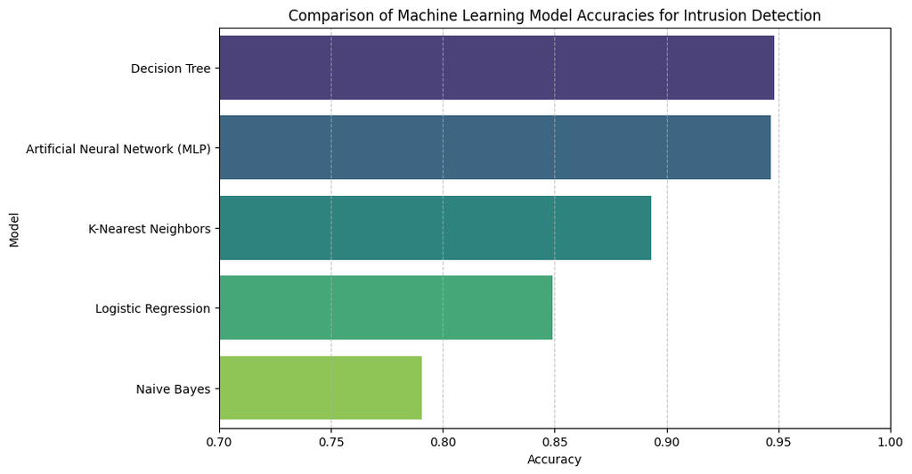

```python
import pandas as pd
import matplotlib.pyplot as plt
import seaborn as sns

# Create a dictionary to store model accuracies
model_accuracies = {
    'Naive Bayes': accuracy_nb,
    'Logistic Regression': accuracy_lr,
    'K-Nearest Neighbors': accuracy_knn,
    'Decision Tree': accuracy_dt,
    'Artificial Neural Network (MLP)': accuracy_mlp
}

# Convert to DataFrame for easier plotting
accuracy_df = pd.DataFrame(list(model_accuracies.items()), columns=['Model', 'Accuracy'])

# Sort by accuracy for better visualization
accuracy_df = accuracy_df.sort_values(by='Accuracy', ascending=False)

print("\nSummary of Model Accuracies:")
display(accuracy_df)

# Plot the accuracies
plt.figure(figsize=(10, 6))
sns.barplot(x='Accuracy', y='Model', data=accuracy_df, palette='viridis')
plt.title('Comparison of Machine Learning Model Accuracies for Intrusion Detection')
plt.xlabel('Accuracy')
plt.ylabel('Model')
plt.xlim(0.7, 1.0) # Set x-axis limit to focus on relevant range
plt.grid(axis='x', linestyle='--', alpha=0.7)
plt.show()
```

Inference: The bar chart clearly illustrates the performance of each model, highlighting the superior accuracy of Decision Tree and MLP models for this intrusion detection task. While Naive Bayes and Logistic Regression provide reasonable baselines, KNN also performs well, but the Decision Tree and MLP demonstrate the best overall predictive power.